# Recalling Words

```r
# Play the chunk above and this one to get the data into your Console
View(Friendly)
?Friendly
```

#### Background

Many teachers and other educators are interested in understanding how to best deliver new content to students. In general, they have two choices of how to do this.

1. The Meshed Approach
   - Deliver new content while simultaneously reviewing previously understood content.
2. The Before Approach
   - Deliver new content after fully reviewing previously understood content.

A study was performed to determine whether the *Meshed* or *Before* approaches to delivering content had any positive benefits on memory recall.

##### The Experiment (click to view)

## Introduction:

The point of my Wilcoxon Rank Sum (Mann-Whitney) Test is to see whether the Meshed Approach to delivering new content to students has a positive benefit on memory recall. The Wilcoxon Rank Sum Test is appropriate for this analysis because the variables are independent variables and the sample size is small (you can see this in my summary code).

## Question:

The question I am trying to answer is:

Does the Meshed Approach to delivering new content to students have a positive benefit on memory recall?

## Hypothesis and Alternative Hypothesis:

$$H_0: \text{difference in medians of the Meshed Approach group and the SFR group=0}$$
$$H_a: \text{difference in medians of the Meshed Approach group and the SFR group>0}$$

(the alternative hypothesis means that the Meshed Approach has a positive benefit on memory recall)

Significance level will be: α=0.05

## Data Analysis:

```r
#Use Wilcox tests when data is not normal OR has a small sample size (<30)

Friendly1 <- droplevels(filter(Friendly, condition %in% c('SFR','Meshed')))

datatable(Friendly1, options=list(lengthMenu = c(10,10)))
```

|  | condition | correct |
| --- | --- | --- |
| 1 | SFR | 39 |
| 2 | SFR | 25 |
| 3 | SFR | 37 |
| 4 | SFR | 25 |
| 5 | SFR | 29 |
| 6 | SFR | 39 |
| 7 | SFR | 21 |
| 8 | SFR | 39 |
| 9 | SFR | 24 |
| 10 | SFR | 25 |

[output cut: 10 more lines]

```r
Friendly1SFR <- filter(Friendly1, condition %in% c('SFR'))

Friendly1Meshed <- filter(Friendly1, condition %in% c('Meshed'))
```

Here is a table of the data I analyze.

```r
summary(Friendly1) %>%
  pander()
```

| condition | correct |
| --- | --- |
| Meshed:10 | Min. :21.00 |
| SFR :10 | 1st Qu.:28.00 |
| NA | Median :36.00 |
| NA | Mean :33.45 |
| NA | 3rd Qu.:39.00 |
| NA | Max. :40.00 |

Here is a summary of the data which shows the sample size of the Meshed and SFR group is 10 for each. Now, I will conduct a QQPlot to see if the data is normally distributed.

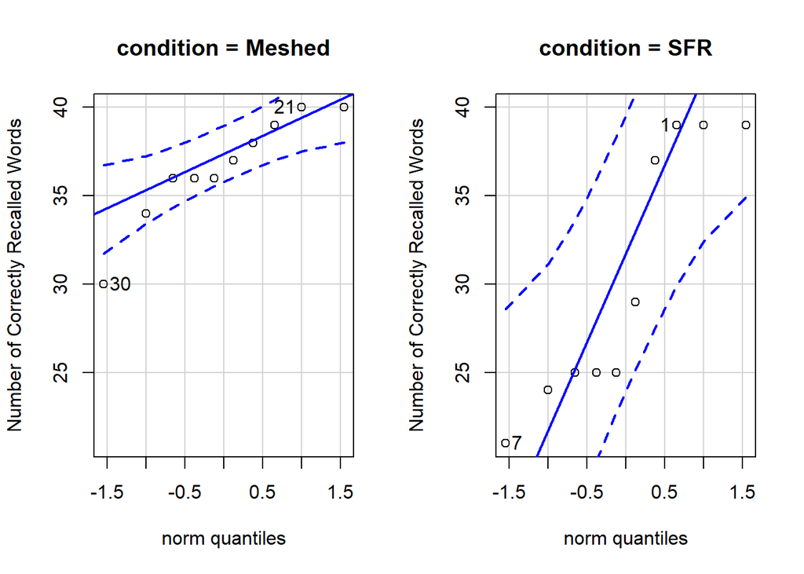

```r
qqPlot(correct ~ condition, data=Friendly1, ylab='Number of Correctly Recalled Words', main='Meshed Group QQPlot')
```

Although the sample size for each group is below 30, the QQPlots show that the data for the Meshed and SFR group is normally distributed. This means we can conduct an independent samples t-test. However, for the purposes of this analysis, we will be conducting a Wilcoxon Rank Sum (Mann-Whitney) Test.

```r
wilcox.test(Friendly1Meshed$correct,Friendly1SFR$correct, mu = 0, alternative = 'greater', conf.level = 0.95) %>%
     pander()
```

Wilcoxon rank sum test with continuity correction: `Friendly1Meshed$correct` and `Friendly1SFR$correct`

| Test statistic | P value | Alternative hypothesis |
| --- | --- | --- |
| 72 | 0.05075 | greater |

My Wilcoxon Rank Sum (Mann-Whitney) Test has insufficient evidence to say that the Meshed Approach has a positive benefit on memory recall. The P-value is 0.05075. This is greater than my alpha of 0.05.

## Graphical Summary:

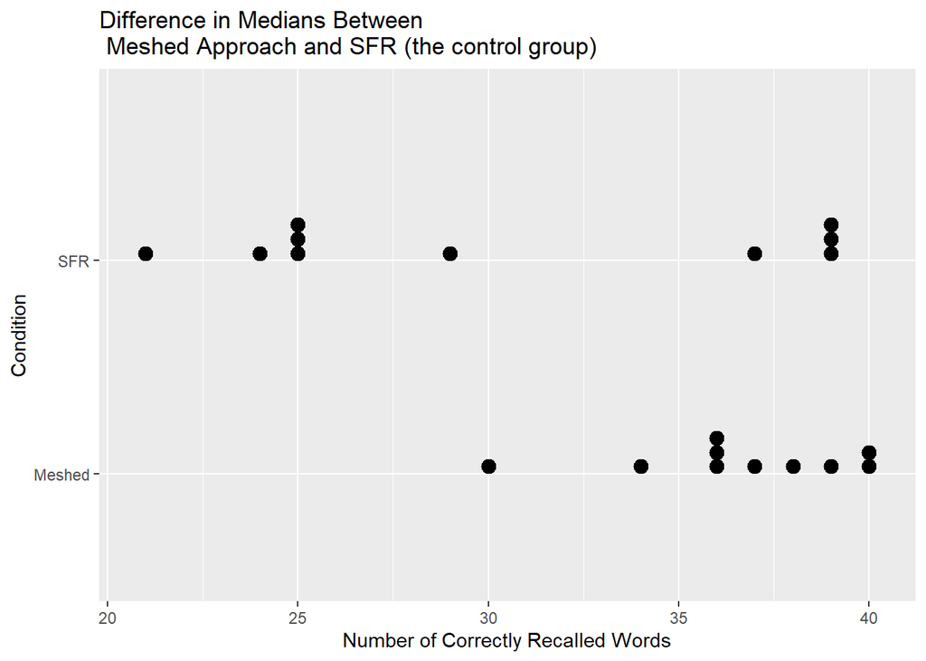

```r
#Use Wilcox tests when data is not normal OR has a small sample size (<30)

ggplot(Friendly1, aes(x=factor(condition), y=correct))+
   coord_flip( )+
   geom_dotplot(binaxis = 'y', stackdir = 'up', position = 'dodge', dotsize = 0.75, binwidth = 0.5)+
   labs(title='Difference in Medians Between \n Meshed Approach and SFR (the control group)', x='Condition', y='Number of Correctly Recalled Words')
```

## Numerical Summary:

```r
#Use Wilcox tests when data is not normal OR has a small sample size (<30)

Friendly1 %>%
    group_by(condition) %>%
    summarise(Min=min(correct),Max=max(correct),Median=median(correct),
              Mean=mean(correct),Sample_Size = n()) %>%
    pander()
```

| condition | Min | Max | Median | Mean | Sample_Size |
| --- | --- | --- | --- | --- | --- |
| Meshed | 30 | 40 | 36.5 | 36.6 | 10 |
| SFR | 21 | 39 | 27 | 30.3 | 10 |

For my numerical summary, I conducted a summary of what is shown in the dot plot. This summary includes the minimum, maximum, median, and mean of the number of correctly recalled words for the SFR (control) group and the Meshed Approach group. The median for the Meshed Approach group is 36.5 and the mean is 36.6. The median for the SFR (control) group is 27 and the mean 30.3.

## Interpretation/Conclusion:

Based off of my Wilcoxon Rank Sum (Mann-Whitney) Test, we have insufficient evidence to say the difference in medians of the Meshed Approach and the SFR group is greater than zero. This means that the Meshed Approach to delivering new content to students does not show better memory recall than the SFR (control) group. The null hypothesis (difference in medians of the Meshed Approach group and the SFR group=0) stands.